# 의학통계방법론 1조 5주차 과제

김재혁, 정지현

2022-04-07

```r
getwd()
```

```
## [1] "C:/git_blog/study/img/ch10"
```

```r
library(readxl)
library(dplyr)
library(kableExtra)
library(randtests)
library(lmtest)
library(car)
library(lawstat)
library(onewaytests)
library(pwr2)
library(pgirmess)
library(DescTools)
library(RVAideMemoire)
```

**엑셀파일불러오기**

```r
#모든 시트를 하나의 리스트로 불러오는 함수
read_excel_allsheets <- function(file, tibble = FALSE) {
  sheets <- readxl::excel_sheets(file)
  x <- lapply(sheets, function(X) readxl::read_excel(file, sheet = X))
  if(!tibble) x <- lapply(x, as.data.frame)
  names(x) <- sheets
  x
}
```

## 0.1 10장

**10장 연습문제 불러오기**

```r
#data_chap10에 연습문제 10장 모든 문제 저장
data_chap10 <- read_excel_allsheets("data_chap10.xls")

#연습문제 각각 데이터 생성
for (x in 1:length(data_chap10)){
  assign(paste0('ex10_',c(1:3,10:13))[x],data_chap10[x])
  }

#연습문제 데이터 형식을 리스트에서 데이터프레임으로 변환
for (x in 1:length(data_chap10)){
  assign(paste0('ex10_',c(1:3,10:13))[x],data.frame(data_chap10[x]))
  }
```

## 0.2 EXAMPLE 10.1

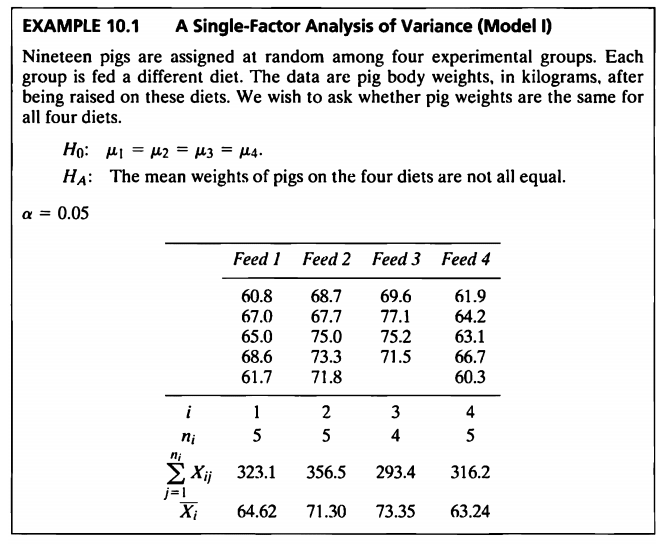

```r
#데이터셋
ex10_1%>%
  kbl(caption = "Dataset",escape=F) %>%
  kable_styling(bootstrap_options = c("striped", "hover", "condensed", "responsive"))
```

Dataset

| exam10_1.id | exam10_1.diet | exam10_1.weight |
| --- | --- | --- |
| 1 | 1 | 60.799999999999997 |
| 2 | 1 | 67 |
| 3 | 1 | 65 |
| 4 | 1 | 68.599999999999994 |
| 5 | 1 | 61.700000000000003 |
| 6 | 2 | 68.700000000000003 |
| 7 | 2 | 67.700000000000003 |
| 8 | 2 | 75 |
| 9 | 2 | 73.299999999999997 |
| 10 | 2 | 71.799999999999997 |
| 11 | 3 | 69.599999999999994 |
| 12 | 3 | 77.099999999999994 |
| 13 | 3 | 75.200000000000003 |
| 14 | 3 | 71.5 |
| 15 | 3 | . |
| 16 | 4 | 61.899999999999999 |
| 17 | 4 | 64.200000000000003 |
| 18 | 4 | 63.100000000000001 |
| 19 | 4 | 66.700000000000003 |
| 20 | 4 | 60.299999999999997 |

**데이터: 19마리 돼지를 4개 그룹으로 무작위로 나누어 서로 다른 다이어트 처리 후 중량(kg) 측정**

- 이 문제의 데이터는 돼지의 체중(weight) 증가에 가장 효율적인 사료(feed)를 찾기 위한 실험에서 얻어진 측정값들이다.
- 19마리의 돼지가 각 처리별로 랜덤배정되었다.
- 사료의 종류에 따라 나뉘어진 네 집단 간 무게의 모평균에 차이가 있는지를 검정할 것이다.

$$\begin{aligned}
H_0&:\ \mu_1=\mu_2=\mu_3=\mu_4.\\
H_A&:\ The\ mean\ weights\ of\ pigs\ on\ the\ four\ diets\ are\ not\
all\ equal.\\
\end{aligned}$$

- 단일 요인 분산 분석 ANOVA는 완전히 랜덤화 된 실험 설계 방법이다.
- “completely randomized design”이라고도 한다.
- 일반적으로 데이터에서 그룹의 통계적 비교는 각 그룹의 데이터 수가 동일한 경우(균형적인 상황)에 가장 적합하다.
- 균형적일 때 검정의 검정력이 높아진다.
- 하지만 10.1의 데이터의 경우 4개의 그룹 각각에 5마리의 실험동물이 있지만,  
  Feed 3에 속한 한 마리의 동물의 몸무게는 어떤 적절한 이유로 분석에 사용되지 않았다.  
  아니면 병이 났거나 임신한 것으로 밝혀졌을 수도 있다.
- 분산 분석에서는 실험 요인을 제외한 모든 면에서 가능한 유사해야 한다.  
  (즉, 동물은 동일한 품종, 성별, 연령이어야 하고, 같은 온도로 유지되어야 한다.)

```r
class(ex10_1$exam10_1.weight)
```

```
## [1] "character"
```

- weight의 class가 character이므로 사용시 numeric으로 변경하여 사용한다.
- 분석을 위한 통계량

```r
ex10_1 %>%
  group_by(exam10_1.diet) %>%
  summarize(mean=mean(as.numeric(exam10_1.weight),na.rm=T),sum=sum(as.numeric(exam10_1.weight),na.rm=T))%>%
  kbl(caption = "Dataset") %>%
  kable_styling(bootstrap_options = c("striped", "hover", "condensed", "responsive"))
```

Dataset

| exam10_1.diet | mean | sum |
| --- | --- | --- |
| 1 | 64.62 | 323.1 |
| 2 | 71.30 | 356.5 |
| 3 | 73.35 | 293.4 |
| 4 | 63.24 | 316.2 |

## 0.3 EXAMPLE 10.1a

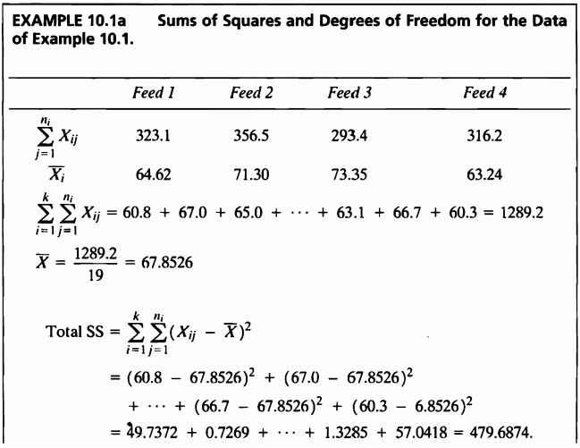

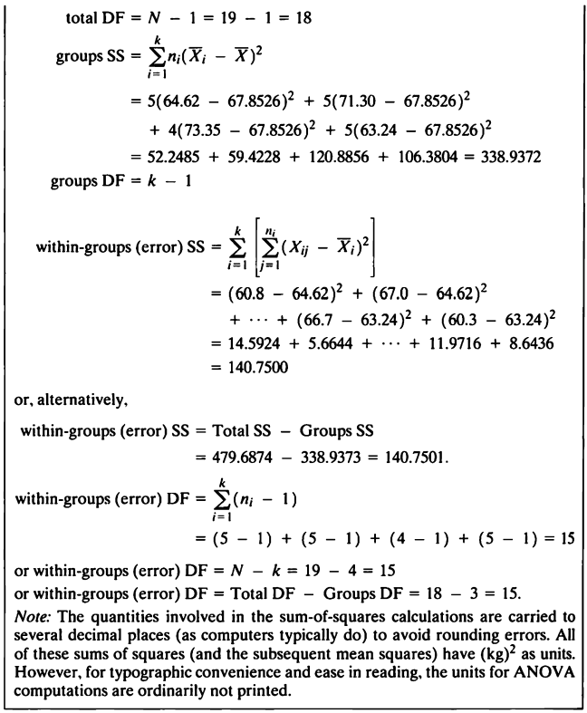

- 분석을 위해 결측치 제거해준 뒤 자유도와 제곱합들을 구하도록 한다.

```r
ex10_1[15,3]=NA
ex10_1<-na.omit(ex10_1)
```

```r
ex10_1a <- function(x){
  sum <- ex10_1 %>% summarize(sum=sum(as.numeric(exam10_1.weight),na.rm=T))
  mean <- ex10_1 %>% summarize(mean=mean(as.numeric(exam10_1.weight),na.rm=T))
  total_df<-length(x)-1
  groups_df<-length(unique(ex10_1$exam10_1.diet))-1
  error_df<-length(x)-length(unique(ex10_1$exam10_1.diet))
  y <- rep(0,4)
  for (i in 1:4){
    y[i]=length(as.numeric(ex10_1[ex10_1$exam10_1.diet==i,3]))*((mean(as.numeric(ex10_1[ex10_1$exam10_1.diet==i,3]))-mean(x))^2)
  }
  SSB=sum(y)
  SST=sum((x-mean(x))^2)
  SSE=SST-SSB
  table <- data.frame(total_DF=total_df,groups_DF=groups_df,error_DF=error_df,Total_SS=SST,Group_SS=SSB,Error_SS=SSE)
  return(table)
}
```

```r
ex10_1a(as.numeric(ex10_1$exam10_1.weight))%>%
  kbl(caption = "Dataset",escape=F) %>%
  kable_styling(bootstrap_options = c("striped", "hover", "condensed", "responsive"))
```

Dataset

| total_DF | groups_DF | error_DF | Total_SS | Group_SS | Error_SS |
| --- | --- | --- | --- | --- | --- |
| 18 | 3 | 15 | 479.6874 | 338.9374 | 140.75 |

## 0.4 EXAMPLE 10.1b

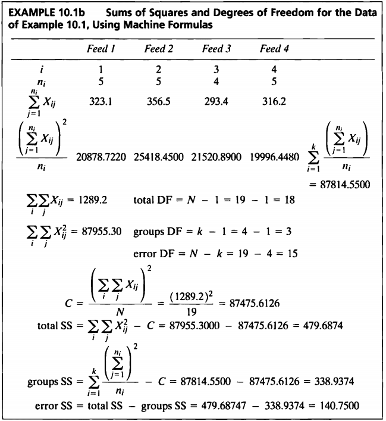

- “Machine Formulas”라는 새로운 방식을 사용한 결과는 다음과 같다.

$$\begin{aligned}
Total\ SS&=\sum_{i=1}^k\ \sum_{j=1}^{n_i}X_{ij}^2-C\\\\
group\ SS&=\sum_{i=1}^k \frac{(\sum_{j=1}^{n_i}X_{ij})^2}{n_i}-C\\\\
error\ SS&=\sum_{i=1}^k\ \sum_{j=1}^{n_i}X_{ij}^2-\sum_{i=1}^k
\frac{(\sum_{j=1}^{n_i}X_{ij})^2}{n_i}\\\\
where\ C&=\frac{(\sum_{i} \sum_{j} \ X_{ij})^2}{N}
\end{aligned}$$

```r
ex10_1b <- function(){
  sum <- ex10_1 %>% summarize(sum=sum(as.numeric(exam10_1.weight),na.rm=T))
  sum_s <- ex10_1 %>% summarize(sum_s=sum((as.numeric(exam10_1.weight))^2,na.rm=T))
  c <- sum^2/length(as.numeric(ex10_1$exam10_1.weight))
  y <- rep(0,4)
  for (i in 1:4){
    y[i]=(sum(as.numeric(ex10_1[ex10_1$exam10_1.diet==i,3]))^2)/(length(as.numeric(ex10_1[ex10_1$exam10_1.diet==i,3])))
  }
  ss <- sum(y)
  tss <- round(sum_s-c,4)
  gss <- (ss-c)
  ess <- (round(sum_s-c,4)-(ss-c))
  table <- data.frame(tss,gss,ess)
  names(table) <- c("Total_SS","Group_SS","Error_SS")
  return(table)
}
```

```r
ex10_1b()%>%
  kbl(caption = "Dataset",escape=F) %>%
  kable_styling(bootstrap_options = c("striped", "hover", "condensed", "responsive"))
```

Dataset

| Total_SS | Group_SS | Error_SS |
| --- | --- | --- |
| 479.6874 | 338.9374 | 140.75 |

- “Machine Formulas” 방법을 사용한 결과와 10.1a에서 구한 결과가 같은 것을 확인할 수 있다.
- 예제 10.1b와 같이 간단한 계산기를 사용할 때 이와 같은 기계식은 매우 편리할 수 있지만, 통계적 계산을 컴퓨터에 의해 수행하는 경우에는 덜 중요하다.

## 0.5 EXAMPLE 10.1c

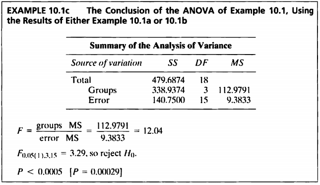

- 10.1a와 10.1b에서 구한 값들을 토대로 ANOVA를 진행하도록 한다.
- 일원분산분석을 진행하기 전에 정규성과 등분산성, 독립성을 만족하는지 부터 확인하도록 한다.

> Shapiro-Wilk test로 네 그룹의 정규성을 평가하였다.

```r
shapiro.test(subset(as.numeric(ex10_1$exam10_1.weight),ex10_1$exam10_1.diet==1));shapiro.test(subset(as.numeric(ex10_1$exam10_1.weight),ex10_1$exam10_1.diet==2));shapiro.test(subset(as.numeric(ex10_1$exam10_1.weight),ex10_1$exam10_1.diet==3));shapiro.test(subset(as.numeric(ex10_1$exam10_1.weight),ex10_1$exam10_1.diet==4))
```

```
##
##  Shapiro-Wilk normality test
##
## data:  subset(as.numeric(ex10_1$exam10_1.weight), ex10_1$exam10_1.diet == 1)
## W = 0.93315, p-value = 0.618
```

```
##
##  Shapiro-Wilk normality test
##
## data:  subset(as.numeric(ex10_1$exam10_1.weight), ex10_1$exam10_1.diet == 2)
## W = 0.94389, p-value = 0.6936
```

```
##
##  Shapiro-Wilk normality test
##
## data:  subset(as.numeric(ex10_1$exam10_1.weight), ex10_1$exam10_1.diet == 3)
## W = 0.95202, p-value = 0.7287
```

```
##
##  Shapiro-Wilk normality test
##
## data:  subset(as.numeric(ex10_1$exam10_1.weight), ex10_1$exam10_1.diet == 4)
## W = 0.99027, p-value = 0.9806
```

- 네 그룹 모두 정규성 검정 결과 p-value가 0.05보다 매우 크므로 네 그룹 모두 모집단이 정규성을 따르지 않는다는 대립가설을 채택할 충분한 근거가 없다.
- 따라서 정규성을 만족한다는 사실을 바탕으로 그룹별 등분산성 검정을 진행한다.

> Bartlett’s Test를 통해 네 그룹의 등분산성 검정을 진행하였다.

```r
bartlett.test(ex10_1$exam10_1.weight~ex10_1$exam10_1.diet)
```

```
##
##  Bartlett test of homogeneity of variances
##
## data:  ex10_1$exam10_1.weight by ex10_1$exam10_1.diet
## Bartlett's K-squared = 0.47515, df = 3, p-value = 0.9243
```

- Bartlett’s Test의 유의확률은 p-value = 0.9243으로 유의수준 0.05보다 매우 크므로 등분산성이 아니라는 대립가설을 채택할 근거가 없다.
- Runs Test와 Durbin-Watson test을 통하여 잔차의 자기상관성을 확인하여 보겠다.

> Runs Test

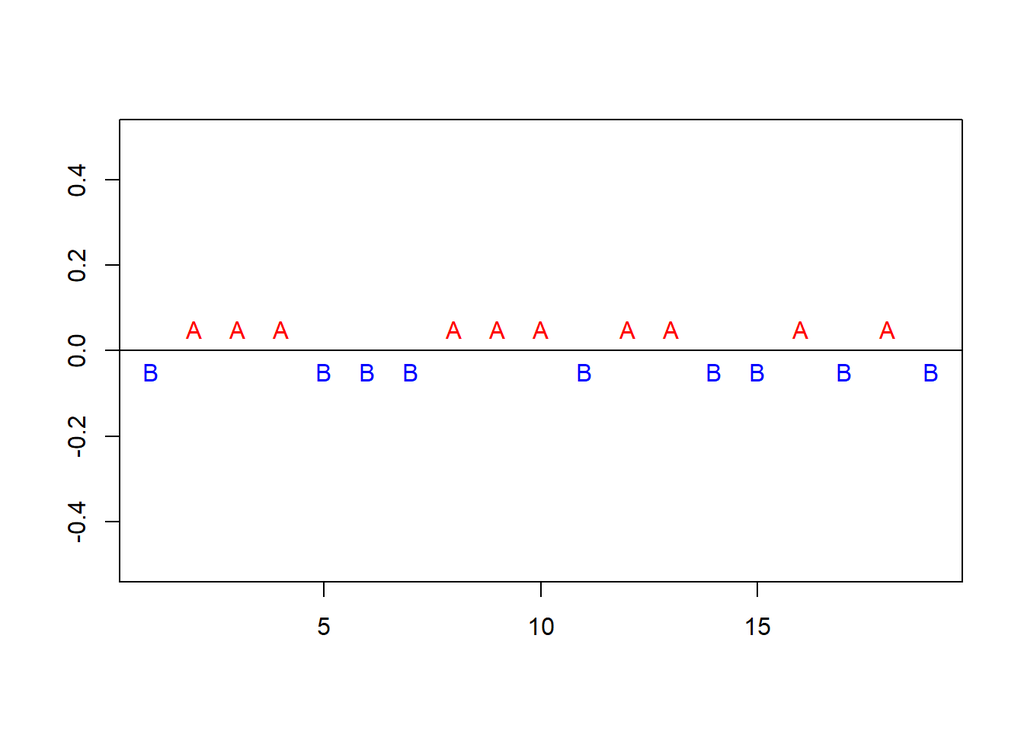

```
##
##  Runs Test - Two sided
##
## data:  anova_ex10_1$residuals
## Standardized Runs Statistic = 0.24922, p-value = 0.8032
```

```r
anova_ex10_1 <- aov(as.numeric(ex10_1$exam10_1.weight)~as.factor(ex10_1$exam10_1.diet))
library(randtests)
runs.test(anova_ex10_1$residuals, alternative = "two.sided", plot = TRUE)
```

-잔차 그림을 확인하여 보면 뚜렷한 패턴이 보이지 않았다.  
- Runs Test의 경우 양의 계열상관을 검정하기 위해서는 하한임계치를 사용하고,  
음의 계열상관을 검정하기 위해서는 상한 임계치를 사용하며, 계열상관의 존재 여부를 위해서는 양쪽 임계치 모두를 사용한다.  
- 양측 검정을 시행하였으며, p-value = 0.8032이므로 귀무가설 “연속적인 관측값이 임의적이다.”를 기각하지 못한다.

> Durbin-Watson test

```r
library(lmtest)
dwtest(anova_ex10_1, alternative = "greater")
```

```
##
##  Durbin-Watson test
##
## data:  anova_ex10_1
## DW = 2.2368, p-value = 0.4203
## alternative hypothesis: true autocorrelation is greater than 0
```

- Durbin-Watson test의 경우 DW = 2.2368으로 4보다 2와 가깝게 나왔으며, 2보다 크므로 alternative = “greater” 주었고 p-value = 0.4203으로 귀무가설 “자기상관이 0 이다.”를 기각하지 못한다.
- 자기상관성이 없다고 독립인 건 아니지만 독립성 가정이 만족된다고 가정할 수 있을 것 같다.
- Shapiro-Wilk test와 Bartlett’s Test으로 정규성과 등분산성을 확인하였으므로 ANOVA 검정을 진행한다.

```r
class(ex10_1$exam10_1.diet)
```

```
## [1] "numeric"
```

- diet의 class가 numeric이므로 factor로 변경해서 ANOVA 검정을 실시한다.

```r
summary(aov(as.numeric(ex10_1$exam10_1.weight)~as.factor(ex10_1$exam10_1.diet)))
```

```
##                                 Df Sum Sq Mean Sq F value   Pr(>F)
## as.factor(ex10_1$exam10_1.diet)  3  338.9  112.98   12.04 0.000283 ***
## Residuals                       15  140.8    9.38
## ---
## Signif. codes:  0 '***' 0.001 '**' 0.01 '*' 0.05 '.' 0.1 ' ' 1
```

- p-value가 0.000283으로 유의수준 0.05보다 매우 작기 때문에 귀무가설을 기각할 수 있고 따라서 유의수준 5%하에 식단에 따른 돼지의 몸무게 모평균 차이가 있다고 말할 수 있다.

## 0.6 EXAMPLE 10.2

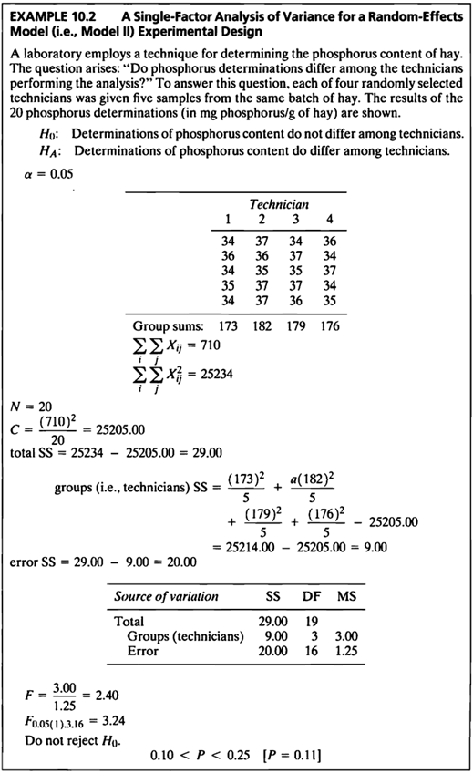

```r
#데이터셋
ex10_2
```

```
##    exam10_2.id exam10_2.technician exam10_2.phosphorus
## 1            1                   1                  34
## 2            2                   1                  36
## 3            3                   1                  34
## 4            4                   1                  35
## 5            5                   1                  34
## 6            6                   2                  37
## 7            7                   2                  36
## 8            8                   2                  35
## 9            9                   2                  37
## 10          10                   2                  37
## 11          11                   3                  34
## 12          12                   3                  37
## 13          13                   3                  35
## 14          14                   3                  37
## 15          15                   3                  36
## 16          16                   4                  36
## 17          17                   4                  34
## 18          18                   4                  37
## 19          19                   4                  34
## 20          20                   4                  35
```

- 실험실에서 건초의 인 함량을 측정하는 기술을 사용하는데  
  “인 측정값이 분석을 수행하는 기술자마다 다릅니까?”라는 질문이 발생한다.
- 이 질문에 답하기 위해 무작위로 선택된 네 명의 기술자 각각에게 동일한 건초 배치에서 5개의 샘플이 주어졌고, 20개의 인 측정 결과(건초 mg/g)가 표시된다.
- Example 10.2는 랜덤 효과 모형에 대한 분산 분석을 보여준다.
- Example 10.2의 심각한 결과는 기본 가정으로부터 이탈하는 경우이다.
- 다행히도 많은 상황에서 분산 분석은 강력한 테스트이며, 이는 제 1종오류, 제 2종오류 확률이 항상 test 가정 위반에 의해 심각하게 변경되는 것은 아니라는 것을 의미한다.
- two-sample t-test과 마찬가지로 비정규성의 부작용은 정규성에서 벗어날수록 더 크지만 표본 크기가 같을 경우 효과는 상대적으로 작다.
- 본 검정의 가설은 다음과 같다.

$$\begin{aligned}
H_0&:\ Determinations\ of\ phosphorus\ content\ do\ not\ differ\
among\ technicians.\\
H_A&:\ Determinations\ of\ phosphorus\ content\ do\ differ\ among\
technicians.\\
\end{aligned}$$

- F 통계량을 구하는 공식은 다음과 같다.

$$\begin{aligned}
\sum_i\ \sum_j\ X_{ij}&=710,\ \ \ \sum_i\ \sum_j\ X_{ij}^2=25234,\ \
\ \ N=20,\ \ \ C=\frac{(710)^2}{20}=25205.00\\
total\ SS&=25234-25202.00=29.00\\group\
SS&=\frac{(173)^2}{5}+\frac{(182)^2}{5}+\frac{(179)^2}{5}+\frac{(176)^2}{5}-25205.00=25214.00-25205.00=9.00\\
error\ SS&=29.00-9.00=20.00\\
F&=\frac{3.00}{1.25}=2.40,\ \ \ \ F_{0.05(1),3,16}=3.24\ \ \ \ Do\
not\ reject\ H_0.\ \ \ \ 0.10<P<0.25[P=0.11]
\end{aligned}$$

- 이를 분산분석을 통해 알아보기 위해 정규성과 등분산성을 만족하는지 확인하도록 한다.

> Shapiro-Wilk test로 네 그룹의 정규성을 평가하였다.

```r
shapiro.test(subset(ex10_2$exam10_2.phosphorus,ex10_2$exam10_2.technician==1));shapiro.test(subset(ex10_2$exam10_2.phosphorus,ex10_2$exam10_2.technician==2));shapiro.test(subset(ex10_2$exam10_2.phosphorus,ex10_2$exam10_2.technician==3));shapiro.test(subset(ex10_2$exam10_2.phosphorus,ex10_2$exam10_2.technician==4))
```

```
##
##  Shapiro-Wilk normality test
##
## data:  subset(ex10_2$exam10_2.phosphorus, ex10_2$exam10_2.technician == 1)
## W = 0.77091, p-value = 0.04595
```

```
##
##  Shapiro-Wilk normality test
##
## data:  subset(ex10_2$exam10_2.phosphorus, ex10_2$exam10_2.technician == 2)
## W = 0.77091, p-value = 0.04595
```

```
##
##  Shapiro-Wilk normality test
##
## data:  subset(ex10_2$exam10_2.phosphorus, ex10_2$exam10_2.technician == 3)
## W = 0.90202, p-value = 0.4211
```

```
##
##  Shapiro-Wilk normality test
##
## data:  subset(ex10_2$exam10_2.phosphorus, ex10_2$exam10_2.technician == 4)
## W = 0.90202, p-value = 0.4211
```

- Shapiro-Wilk test로 1,2 그룹은 모두 정규성 검정한 결과 p-value가 0.05보다 작으므로 모집단이 정규성을 따르지 않는다는 대립가설을 채택할 충분한 근거가 있고, 3,4 그룹은 모두 정규성 검정한 결과 p-value가 0.05보다 매우 크므로 모집단이 정규성을 따르지 않는다는 대립가설을 채택할 충분한 근거가 없다.
- 등분산성 검정으로 Bartlett’s Test가 아닌 normal상태가 아닌것에 대해 덜 민감한 Levene’s Test를 진행하여 보자.

```r
class(ex10_2$exam10_2.technician)
```

```
## [1] "numeric"
```

- technician의 class가 numeric이므로 factor로 변경해서 등분산성 검정을 실시한다.
- R에서 car, lawstat 패키지에서 Levene’s Test를 제공하여 준다.

> Levene’s Test를 통해 네 그룹의 등분산성 검정을 진행하였다.

```r
library(car)
leveneTest(ex10_2$exam10_2.phosphorus~as.factor(ex10_2$exam10_2.technician),center=mean)
```

```
## Levene's Test for Homogeneity of Variance (center = mean)
##       Df F value Pr(>F)
## group  3  0.6827 0.5755
##       16
```

```r
library(lawstat)
levene.test(ex10_2$exam10_2.phosphorus,as.factor(ex10_2$exam10_2.technician), location="mean")
```

```
##
##  Classical Levene's test based on the absolute deviations from the mean
##  ( none not applied because the location is not set to median )
##
## data:  ex10_2$exam10_2.phosphorus
## Test Statistic = 0.68267, p-value = 0.5755
```

- p-value = 0.5755으로 유의수준 0.05보다 매우 크므로 등분산성이 아니라는 대립가설을 채택할 근거가 없다.
- Runs Test와 Durbin-Watson test을 통하여 잔차의 자기상관성을 확인하여 보겠다.

> Runs Test

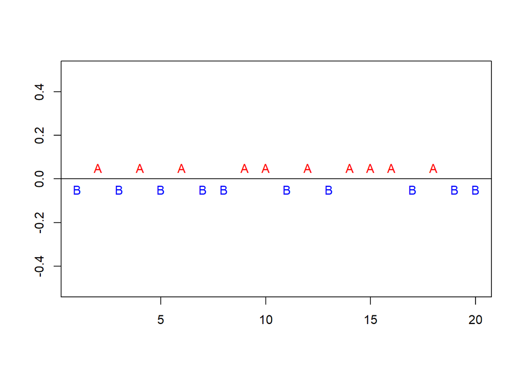

```
##
##  Runs Test - Two sided
##
## data:  anova_ex10_2$residuals
## Standardized Runs Statistic = 1.8379, p-value = 0.06608
```

```r
anova_ex10_2 <- aov(ex10_2$exam10_2.phosphorus~as.factor(ex10_2$exam10_2.technician))
runs.test(anova_ex10_2$residuals, alternative = "two.sided", plot = TRUE)
```

- p-value = 0.06608로써 만족스럽게 귀무가설을 기각하지 못하였다.

> Durbin-Watson test

```r
dwtest(anova_ex10_2, alternative = "greater")
```

```
##
##  Durbin-Watson test
##
## data:  anova_ex10_2
## DW = 3.228, p-value = 0.994
## alternative hypothesis: true autocorrelation is greater than 0
```

- Durbin-Watson test의 경우 DW = 3.228로써 4에 가까운 값이 나왔으며, 2보다 크므로 alternative = “greater” 주었고 p-value = 0.994로 귀무가설 “자기상관이 0 이다.”를 기각하지 못한다.
- 자기상관성이 없다고 독립인 건 아니지만 독립성 가정이 만족된다고 가정할 수 있을 것 같다.
- 표본이 정규분포를 따르지 않지만 유사한 분포를 가지고 있고 분산도 유사하다면 Kruskal-Wallis Test가 적절하다.

```r
kruskal.test(ex10_2$exam10_2.phosphorus~as.factor(ex10_2$exam10_2.technician))
```

```
##
##  Kruskal-Wallis rank sum test
##
## data:  ex10_2$exam10_2.phosphorus by as.factor(ex10_2$exam10_2.technician)
## Kruskal-Wallis chi-squared = 6.0065, df = 3, p-value = 0.1113
```

- Kruskal-Wallis Test 결과 p-value가 0.1113으로 유의수준 0.05 보다 크기 때문에 귀무가설을 기각할 수 없고 따라서 유의수준 5%하에 인 함량의 모평균이 기술자마다 다르다고 말할만한 충분한 근거가 없다고 말할 수 있다.

## 0.7 EXAMPLE 10.3

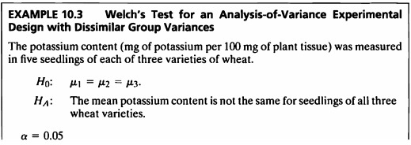

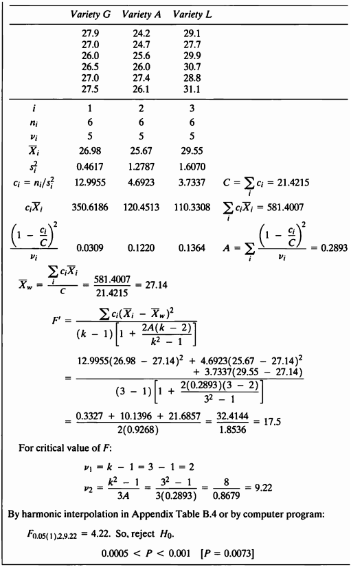

```r
#데이터셋
ex10_3
```

```
##    exam10_3.id exam10_3.variety exam10_3.potassium
## 1            1                1               27.9
## 2            2                1               27.0
## 3            3                1               26.0
## 4            4                1               26.5
## 5            5                1               27.0
## 6            6                1               27.5
## 7            7                2               24.2
## 8            8                2               24.7
## 9            9                2               25.6
## 10          10                2               26.0
## 11          11                2               27.4
## 12          12                2               26.1
## 13          13                3               29.1
## 14          14                3               27.7
## 15          15                3               29.9
## 16          16                3               30.7
## 17          17                3               28.8
## 18          18                3               31.1
```

- 포타슘 함량(식물 조직 100mg당 포타슘의 mg)은 세 가지 종류의 밀 각각 6개의 모종에서 측정되었다.
- 본 검정의 가설은 다음과 같다.

$$\begin{aligned}
H_0&:\ \mu_1=\mu_2=\mu_3\\
H_A&:\ The\ mean\ potassium\ content\ is\ not\ the\ same\ for\
seedlings\ of\ all\ three\ wheat\ varieties.\\
\end{aligned}$$

$$\begin{aligned}
F'&=\frac{\sum_{i=1}^k\
c_i(\bar{X}_i-\bar{X}_w)^2}{(k-1)[1+\frac{2A(k-2)}{K^2-1}]}\\\\
c_i&=\frac{n_i}{s_i^2},\ \ \ \ \ C=\sum_{i=1}^kc_i,\ \ \ \ \
\bar{X_w}=\frac{\sum_{i=1}^kc_i\bar{X_i}}{C},\ \ \
A=\sum_{i=1}^k\frac{(1-\frac{c_i}{C})^2}{v_i},\ where\ v_i=n_i-1 \\
For & \ critical \ value \ of \ F: \ v_1=k-1, \ v_2=\frac{k^2-1}{3A}
\end{aligned}$$

> Shapiro-Wilk test로 네 그룹의 정규성을 평가하였다.

```r
shapiro.test(subset(ex10_3$exam10_3.potassium,ex10_3$exam10_3.variety==1));shapiro.test(subset(ex10_3$exam10_3.potassium,ex10_3$exam10_3.variety==2));shapiro.test(subset(ex10_3$exam10_3.potassium,ex10_3$exam10_3.variety==3))
```

```
##
##  Shapiro-Wilk normality test
##
## data:  subset(ex10_3$exam10_3.potassium, ex10_3$exam10_3.variety == 1)
## W = 0.9778, p-value = 0.9401
```

```
##
##  Shapiro-Wilk normality test
##
## data:  subset(ex10_3$exam10_3.potassium, ex10_3$exam10_3.variety == 2)
## W = 0.96651, p-value = 0.8682
```

```
##
##  Shapiro-Wilk normality test
##
## data:  subset(ex10_3$exam10_3.potassium, ex10_3$exam10_3.variety == 3)
## W = 0.96881, p-value = 0.8844
```

- Shapiro-Wilk test 결과 p-value가 0.05보다 매우 크므로 세 그룹 모두 모집단이 정규성을 따르지 않는다는 대립가설을 채택할 충분한 근거가 없다.
- 따라서 정규성을 만족한다는 사실을 바탕으로 그룹별 등분산성 검정을 진행한다.

```r
class(ex10_3$exam10_3.variety)
```

```
## [1] "numeric"
```

- variety의 class가 numeric이므로 factor로 변경해서 등분산성 검정을 실시한다.

> Bartlett’s Test를 통해 네 그룹의 등분산성 검정을 진행하였다.

```r
bartlett.test(ex10_3$exam10_3.potassium~as.factor(ex10_3$exam10_3.variety))
```

```
##
##  Bartlett test of homogeneity of variances
##
## data:  ex10_3$exam10_3.potassium by as.factor(ex10_3$exam10_3.variety)
## Bartlett's K-squared = 1.7512, df = 2, p-value = 0.4166
```

- Bartlett’s Test의 유의확률은 p-value = 0.4166으로 유의수준 0.05보다 매우 크므로 등분산성이 아니라는 대립가설을 채택할 근거가 없다.
- Runs Test와 Durbin-Watson test을 통하여 잔차의 자기상관성을 확인하여 보겠다.

> Runs Test

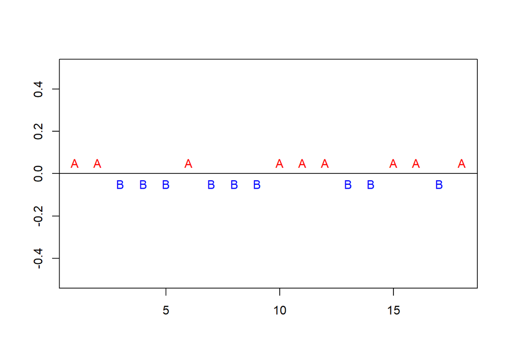

```
##
##  Runs Test - Two sided
##
## data:  anova_ex10_3$residuals
## Standardized Runs Statistic = -0.48591, p-value = 0.627
```

```r
anova_ex10_3 <- aov(ex10_3$exam10_3.potassium~as.factor(ex10_3$exam10_3.variety))
runs.test(anova_ex10_3$residuals, alternative = "two.sided", plot = TRUE)
```

> Durbin-Watson test

```r
dwtest(anova_ex10_3, alternative = "less")
```

```
##
##  Durbin-Watson test
##
## data:  anova_ex10_3
## DW = 1.7019, p-value = 0.8811
## alternative hypothesis: true autocorrelation is less than 0
```

- Durbin-Watson test의 경우 DW = 1.7019로써 0보다 2와 가깝게 나왔으며, 2보다 작으므로 alternative = “less” 주었고 p-value = 0.8811로 귀무가설 “자기상관이 0 이다.”를 기각하지 못한다.
- 자기상관성이 없다고 독립인 건 아니지만 독립성 가정이 만족된다고 가정할 수 있을 것 같다.
- Shapiro-Wilk test와 Bartlett’s Test으로 정규성과 등분산성을 확인하였으므로 ANOVA 검정을 진행한다.

```r
summary(aov(ex10_3$exam10_3.potassium~as.factor(ex10_3$exam10_3.variety)))
```

```
##                                    Df Sum Sq Mean Sq F value   Pr(>F)
## as.factor(ex10_3$exam10_3.variety)  2  46.80  23.402   20.97 4.52e-05 ***
## Residuals                          15  16.74   1.116
## ---
## Signif. codes:  0 '***' 0.001 '**' 0.01 '*' 0.05 '.' 0.1 ' ' 1
```

- p-value가 0.0000452으로 유의수준 0.05보다 매우 작기 때문에 귀무가설을 기각할 수 있고 따라서 유의수준 5%하에 그룹에 따라 밀의 칼륨 함유량의 모평균이 다르다고 말할 수 있다.  
  -이 문제의 데이터는 정규성 가정과 등분산 가정을 만족하여 일원분산분석을 시행할 수 있지만, 문제에 나와 있는 대로 Welch’s test를 수행하도록 하겠다.
- Welch’s test란 표본의 정규성은 만족되지만 그룹별 분산이 동일하지 않은 경우에 매우 강력한 검정이다.

> Welch’s test

```r
library(onewaytests)
welch.test(ex10_3$exam10_3.potassium~as.factor(ex10_3$exam10_3.variety),data=ex10_3)
```

```
##
##   Welch's Heteroscedastic F Test (alpha = 0.05)
## -------------------------------------------------------------
##   data : ex10_3$exam10_3.potassium and as.factor(ex10_3$exam10_3.variety)
##
##   statistic  : 15.0096
##   num df     : 2
##   denom df   : 9.218254
##   p.value    : 0.00126072
##
##   Result     : Difference is statistically significant.
## -------------------------------------------------------------
```

- onewqy.test()에서 var.equal=F를 주면 같은 결과를 출력하여 준다.

```r
oneway.test(ex10_3$exam10_3.potassium~as.factor(ex10_3$exam10_3.variety),var.equal=F)
```

```
##
##  One-way analysis of means (not assuming equal variances)
##
## data:  ex10_3$exam10_3.potassium and as.factor(ex10_3$exam10_3.variety)
## F = 15.01, num df = 2.0000, denom df = 9.2183, p-value = 0.001261
```

- Welch’s test 결과도 동일하게 p-value가 유의수준 0.05보다 매우 작기 때문에 귀무가설을 기각할 수 있고 따라서 유의수준 5%하에 그룹에 따라 밀의 칼륨 함유량의 모평균이 다르다고 말할 수 있다.

## 0.8 EXAMPLE 10.4

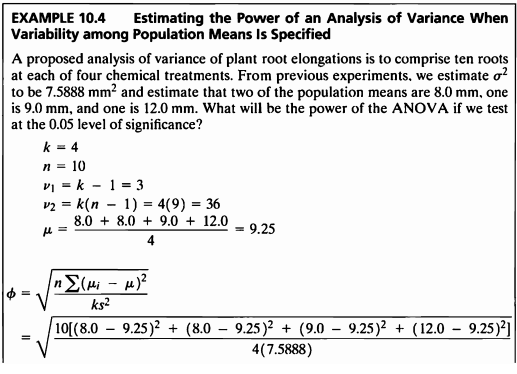

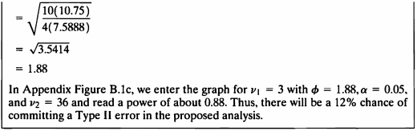

- 식물 뿌리 신장의 분산에 대한 제안된 분석은 4가지 화학 처리 각각에서 10개의 뿌리를 포함하는 것이다.
- 실험을 수행하고 실험에서 데이터를 수집하기 전에 제안된 시험의 검정력을 추정하는 것이 적절하고 바람직하다.
- 검정력을 계산할 때 대립가설 하에서 계산을 하게된다.
- 그 때 나오는 검정통계량은
  $$\phi$$
  를 따르게 되며 이를 구하는 공식및 결과는 다음과 같다.

$$\begin{aligned}
\phi&=\sqrt{\frac{n\sum{(\mu_i-\mu)^2}}{ks^2}} \\
\mu&=\frac{\sum_{i=1}^k{\mu_i}}{k}
\end{aligned}$$

- 문제에서 주어진 조건 하에서의 검정력을 구해 보자.

$$\begin{aligned}
k&=4,\ \ \ \ \ \ \ \ \ n=10,\ \ \ \ \ \ \ \nu_1=k-1=3,\ \ \ \ \ \
\ \nu_2=k(n-1)=4(9)=36,\ \ \ \ \ \ \
\mu=\frac{8.0+8.0+9.0+12.0}{4}=9.25\\\\
\phi&=\sqrt{\frac{n\sum{(\mu_i-\mu)^2}}{ks^2}}=1.88
\end{aligned}$$

```r
groups<-c(8,8,9,12)
power.anova.test(groups=4, n=10, between.var =var(groups), within.var = 7.5888, sig.level = 0.05, power=NULL)
```

```
##
##      Balanced one-way analysis of variance power calculation
##
##          groups = 4
##               n = 10
##     between.var = 3.583333
##      within.var = 7.5888
##       sig.level = 0.05
##           power = 0.8621031
##
## NOTE: n is number in each group
```

- power=0.862로 높게 나왔다.
- 모집단 평균 간의 변동성이 지정된 경우 분산 분석의 검정력을 구할 수 있는 공식에 따라
  $$\phi=1.88$$
  나온다.
- 이를 이용해 power and sample size in analysis of variance: ν1=3 그래프에서
  $$\phi=1.88$$
  일때를 보면 그때의 검정력은 대략 0.88이고 이는 대립가설 하에서 제2종 오류를 범할 확률이 12%임을 의미한다.

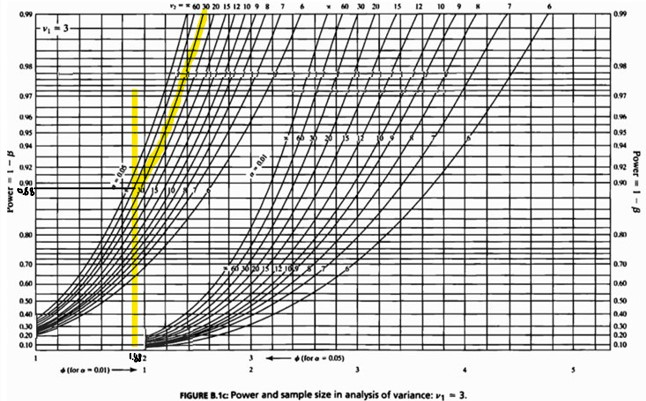

## 0.9 EXAMPLE 10.5

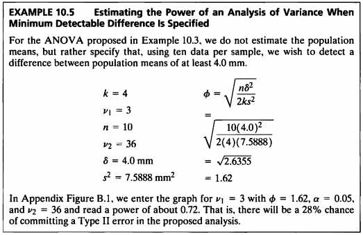

- 최소 검출차가 주어졌을 때 분산의 검정력을 구하는 문제로써 구하는 공식은 다음과 같다.

$$\begin{aligned}
\phi&=\sqrt{\frac{n\delta^2}{2ks^2}}
\end{aligned}$$

> 공식을 함수로 작성하였다.

```r
sample_size <- function(d,k,s,n){
  phi=sqrt((n*d^2)/(2*k*s))
  sample=data.frame(phi)
  return(sample)
}
```

- 문제에서 주어진 조건하에 공식에 대입하여 보자.

$$\begin{aligned}
k&=4,\ \ \ \ \ \ \ \ \ n=10,\ \ \ \ \ \ \ \nu_1=3,\ \ \ \ \ \
\ \nu_2=36,\ \ \ \ \ \delta=4.0mm,\ \ \ \ \ \ s^2=7.5888mm^2\\\\
\phi&=\sqrt{\frac{n\delta^2}{2ks^2}}=1.62
\end{aligned}$$

- 작성한 sample_size 공식에 대입하여
  $$\phi$$
  를 구하였다.

```r
sample_size(d=4, k=4, s=7.5888, n=10)%>%
  kbl(caption = "Result") %>%
  kable_styling(bootstrap_options = c("striped", "hover", "condensed", "responsive"))
```

Result

| phi |
| --- |
| 1.623411 |

- 다음은 pwr.1way 함수를 이용하여 power을 구하였다.

```r
library(pwr2)
n <- 10
k <- 4
s2 <- 7.5888
delta<-4.0
phi<-round(sqrt((n*delta^2)/(2*k*s2)),2)
pwr.1way(k=4, n=10,f=NULL, alpha = 0.05, delta=4.0, sigma=sqrt(7.5888))
```

```
##
##      Balanced one-way analysis of variance power calculation
##
##               k = 4
##               n = 10
##           delta = 4
##           sigma = 2.754778
##     effect.size = 0.5133676
##       sig.level = 0.05
##           power = 0.7348545
##
## NOTE: n is number in each group, total sample = 40 power = 0.734854517715498
```

- power=0.735로 나왔다.
- 최소 검출 차가 지정된 경우 분산 분석의 검정력을 구할 수 있는 공식에 따라
  $$\phi=1.62$$
  가 나온다
- 이를 이용해 power and sample size in analysis of variance: ν1=3 그래프에서
  $$\phi=1.62$$
  일때를 보면 그때의 검정력은 대략 0.72이고 이는 대립가설 하에서 제2종 오류를 범할 확률이 28%임을 의미한다.
- 최소 탐지 가능한 차이가 지정된 경우 anova test의 power를 테스트하는 Balanced one-way analysis of variance power calculation 방법을 이용해 검정력을 구한 결과 또한 power=0.73으로 직접 구한 수치와 매우 유사한것을 볼 수 있다.

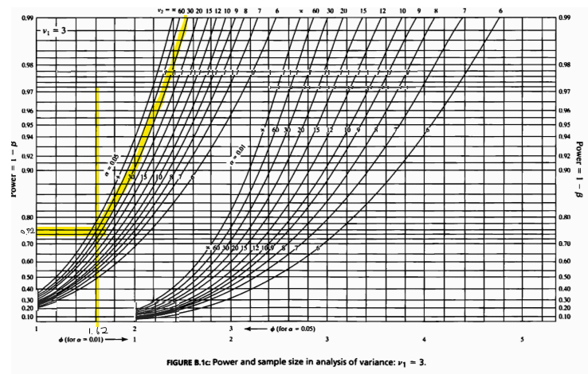

• 그룹 평균 간의 차이가 클수록 검정력은 커진다.

• 검정력은 표본 크기가 클수록 크다.

• 검정력은 더 적은 수의 그룹이 더 크다.

• 군내 변동성이 작을 경우 검정력이 더 크다.

• 검정력은 유의수준이 클수록 크다.

## 0.10 EXAMPLE 10.6

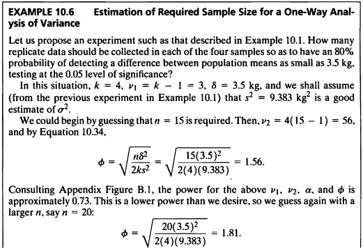

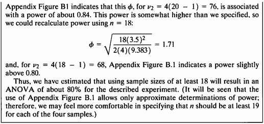

- One-Way Analysis of Variance 에서 필요한 샘플사이즈를 구해보도록 한다.
- 80%의 확률로 3.5kg 만큼의 차이를 탐지하기 위해 필요한 샘플사이즈를 계산하여 보겠다.

$$\begin{aligned}
k&=4,\ \ \ \ \ \ \ \ \ \nu_1=3,\ \ \ \ \ \ \ \ \delta=3.5kg,\ \ \ \
\ \ s^2=9.383kg^2\\\\
\phi&=\sqrt{\frac{n\delta^2}{2ks^2}}
\end{aligned}$$

> 각 그룹에 대해 15만큼의 샘플이 필요하다고 가정하자

```r
sample_size(d=3.5, k=4, s=9.383, n=15)%>%
  kbl(caption = "Result") %>%
  kable_styling(bootstrap_options = c("striped", "hover", "condensed", "responsive"))
```

Result

| phi |
| --- |
| 1.56458 |

- 각 그룹에 대해 15만큼의 샘플이 필요하다고 가정하면
  $$\phi=1.5645$$
  이고 표에서 찾아보면 이는 73%의 검정력에 해당한다.

> 각 그룹에 대해 20만큼의 샘플이 필요하다고 가정하자

```r
sample_size(d=3.5, k=4, s=9.383, n=20)%>%
  kbl(caption = "Result") %>%
  kable_styling(bootstrap_options = c("striped", "hover", "condensed", "responsive"))
```

Result

| phi |
| --- |
| 1.806622 |

- 각 그룹에 대해 20만큼의 샘플이 필요하다고 가정하면
  $$\phi=1.80622$$
  이고 표에서 찾아보면 이는 84%의 검정력에 해당한다.

> 각 그룹에 대해 18만큼의 샘플이 필요하다고 가정하자

```r
sample_size(d=3.5, k=4, s=9.383, n=18)%>%
  kbl(caption = "Result") %>%
  kable_styling(bootstrap_options = c("striped", "hover", "condensed", "responsive"))
```

Result

| phi |
| --- |
| 1.713912 |

- 각 그룹에 대해 18만큼의 샘플이 필요하다고 가정하면
  $$\phi=1.713912$$
  이고 표에서 찾아보면 이는 80%의 검정력에 거의 일치한다.
- 따라서 80% 이상의 검정력을 갖기 위해 필요한 최소한의 그룹별 샘플 사이즈는 18이라고 볼 수 있다.

## 0.11 EXAMPLE 10.7

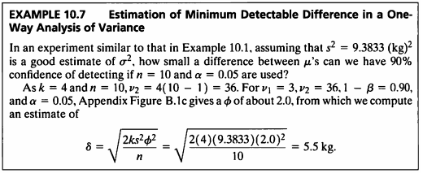

- One-Way Analysis of Variance 에서 최소검출차를 구해보도록 한다.
- ex10_1의 데이터를 이용하여 최소 검출차를 추정하기 위해 다음과 같은 공식을 이용하자.

$$\begin{aligned}
\delta&=\sqrt{\frac{2ks^2\phi^2}{n}}
\end{aligned}$$

- 주어진 대로 공식을 함수로 작성하였다.

```r
Minimum_Detectable_Difference <- function(k,s,p,n){
  delta=sqrt((2*k*s*p^2)/n)
  mdd = data.frame(delta)
  return(mdd)
}
```

> 검정력: 90%, 그룹수: 4, 그룹별 샘플 수: 10, 유의수준: 0.05일 때 탐지할 수 있는 최소 검출차

```r
Minimum_Detectable_Difference(k=4, s=9.3833, p=2.0, n=10)%>%
  kbl(caption = "Result") %>%
  kable_styling(bootstrap_options = c("striped", "hover", "condensed", "responsive"))
```

Result

| delta |
| --- |
| 5.47965 |

- 검정력이 90%이고 그룹수는 4, 그룹별 샘플 수는 10, 유의수준은 0.05일 때 탐지할 수 있는 최소 검출차는
  $$\delta=5.5$$
  로 계산되었다.
- 따라서 효과크기(최소검출차)=5.5일 때 집단간 차이가 유의하게 나타난다고 할 수 있다.

## 0.12 EXAMPLE 10.8

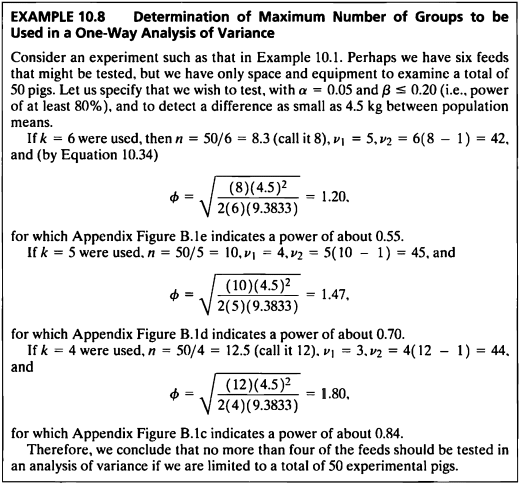

- ex10_1과 같은 실험을 생각하여 볼 때 다음과 같은 가정을 하여보자.
- 6개의 사료를 테스트할 수 있지만, 총 50마리의 돼지를 검사할 수 있는 공간과 장비만 가지고 있다고 하자.  
  유의수준 0.05, 80이상의 검정력으로 테스트하고 모집단 평균 간의 4.5kg의 작은 차이를 발견하고자 한다.
- One-Way Analysis of Variance에서 검정력과 유의수준이 정해져 있을 때 필요한 최대 그룹수를 구하도록 해본다.

$$\begin{aligned}
\alpha&=0.05,\ \ \ \beta\leq0.20(power\ of\ at\ least\ 0.8),\ \ \ \
\delta=4.5\\
If\ k&=6,\ then\ n=\frac{50}{6}=8.3, \ \ \ \nu_1=5, \nu_2=6(8-1)=42
\end{aligned}$$

> 그룹 수 6으로 가정하자

```r
sample_size(d=4.5, k=6, s=9.383, n=8)%>%
  kbl(caption = "Result") %>%
  kable_styling(bootstrap_options = c("striped", "hover", "condensed", "responsive"))
```

Result

| phi |
| --- |
| 1.199488 |

- 그룹 수 6으로 가정하면
  $$\phi=1.199488$$
  이다.

> 그룹 수 5로 가정하자

```r
sample_size(d=4.5, k=5, s=9.383, n=10)%>%
  kbl(caption = "Result") %>%
  kable_styling(bootstrap_options = c("striped", "hover", "condensed", "responsive"))
```

Result

| phi |
| --- |
| 1.469067 |

- 그룹 수 5로 가정하면
  $$\phi=1.469067$$
  이다.

> 그룹 수 4로 가정하자

```r
sample_size(d=4.5, k=4, s=9.383, n=12)%>%
  kbl(caption = "Result") %>%
  kable_styling(bootstrap_options = c("striped", "hover", "condensed", "responsive"))
```

Result

| phi |
| --- |
| 1.799233 |

## 0.13 EXAMPLE 10.9

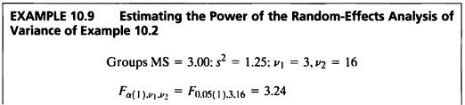

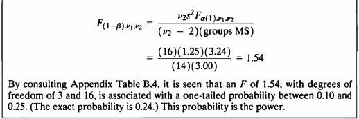

- 랜덤효과가 있는 분선분석의 검정력을 산출하는 공식은 다음과 같다.

$$\begin{aligned}
Random-Effects\ of\ ANOVA&: \
F_{(1-\beta),\nu_1,\nu_2}=\frac{\nu_2s^2F_{\alpha(1),\nu_1,\nu_2}}{(\nu_2-2)(groups\
MS)}
\end{aligned}$$

- Example 10.2 데이터의 결과를 사용하여 ANOVA에서의 Random-Effect모델에서의 power를 구하여 보자.

$$\begin{aligned}
Groups\ MS&=3.00,\ \ \ \ \ s^2=1.25,\ \ \ \ \ \nu_1=3,\ \ \ \
\nu_2=16\\\\
F_{\alpha(1),\nu_1,\nu_2}&=F_{0.05(1),3,16}=3.24\\\\
Random-Effects\ of\ ANOVA&:
F_{(1-\beta),\nu_1,\nu_2}=\frac{\nu_2s^2F_{\alpha(1),\nu_1,\nu_2}}{(\nu_2-2)(groups\
MS)}=1.54
\end{aligned}$$

```r
random_effect<-function(v1, v2, s, alpha, ms){
  F=((v2*s*qf(alpha, v1, v2, lower.tail = F))/((v2-2)*ms))
  f=data.frame(F)
  return(f)
}
```

- 계산 결과 F값은 1.54로 나왔으며, 이는 F분포표에서 자유도는 3과 16, 1-β 값이 0.1과 0.25 사이일 때 값임을 확인할 수 있다.
- 따라서 정확한 수치를 알수는 없지만 이들 사이의 값이 해당 분석의 검정력임을 알 수 있다.

```r
random_effect(3, 16, 1.25, 0.05, 3.0)%>%
  kbl(caption = "Result") %>%
  kable_styling(bootstrap_options = c("striped", "hover", "condensed", "responsive"))
```

Result

| F |
| --- |
| 1.54232 |

```r
F_value <- random_effect(3, 16, 1.25, 0.05, 3.0)[1,]
pf(F_value, 3, 16, lower.tail = F)
```

```
## [1] 0.2421396
```

- 이 랜덤효과 모델의 검정력은 약 0.24임을 알 수 있다.

## 0.14 EXAMPLE 10.10

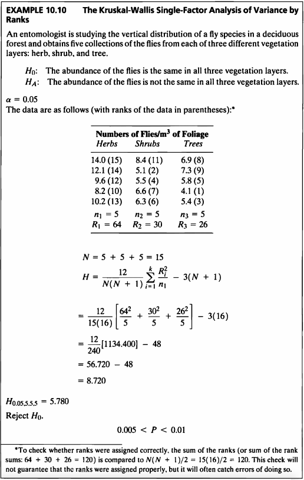

```r
#데이터셋
ex10_10%>%
  kbl(caption = "Dataset",escape=F) %>%
  kable_styling(bootstrap_options = c("striped", "hover", "condensed", "responsive"))
```

Dataset

| exam10_10.id | exam10_10.layer | exam10_10.abundance |
| --- | --- | --- |
| 1 | 1 | 14.0 |
| 2 | 1 | 12.1 |
| 3 | 1 | 9.6 |
| 4 | 1 | 8.2 |
| 5 | 1 | 10.2 |
| 6 | 2 | 8.4 |
| 7 | 2 | 5.1 |
| 8 | 2 | 5.5 |
| 9 | 2 | 6.6 |
| 10 | 2 | 6.3 |
| 11 | 3 | 6.9 |
| 12 | 3 | 7.3 |
| 13 | 3 | 5.8 |
| 14 | 3 | 4.1 |
| 15 | 3 | 5.4 |

- 한 곤충학자는 낙엽 활엽수림에서 파리 종의 수직 분포를 연구하고 있으며,  
  세 가지 다른 식물 층인 허브, 관목, 나무에서 각각 다섯 개의 파리 모음을 얻는다.
- 세 초목에 따른 파리들의 모이는 수의 분산에 차이가 있는지 검정해보도록 한다.

> Shapiro-Wilk test로 세 그룹의 정규성을 평가하였다.

```r
shapiro.test(subset(ex10_10$exam10_10.abundance,ex10_10$exam10_10.layer==1));shapiro.test(subset(ex10_10$exam10_10.abundance,ex10_10$exam10_10.layer==2));shapiro.test(subset(ex10_10$exam10_10.abundance,ex10_10$exam10_10.layer==3))
```

```
##
##  Shapiro-Wilk normality test
##
## data:  subset(ex10_10$exam10_10.abundance, ex10_10$exam10_10.layer == 1)
## W = 0.97015, p-value = 0.8762
```

```
##
##  Shapiro-Wilk normality test
##
## data:  subset(ex10_10$exam10_10.abundance, ex10_10$exam10_10.layer == 2)
## W = 0.92329, p-value = 0.5514
```

```
##
##  Shapiro-Wilk normality test
##
## data:  subset(ex10_10$exam10_10.abundance, ex10_10$exam10_10.layer == 3)
## W = 0.95891, p-value = 0.8004
```

- Shapiro-Wilk test로 1,2,3 그룹 모두 정규성 검정한 결과 p-value가 0.05보다 매우 크므로 모집단이 정규성을 따르지 않는다는 대립가설을 채택할 충분한 근거가 없다.
- 등분산성 검정으로 Bartlett’s Test를 진행하여 보자.

```r
class(ex10_10$exam10_10.layer)
```

```
## [1] "numeric"
```

- layer의 class가 numeric이므로 factor로 변경해서 등분산성 검정을 실시한다.

> Bartlett’s Test를 통해 네 그룹의 등분산성 검정을 진행하였다.

```r
bartlett.test(ex10_10$exam10_10.abundance~as.factor(ex10_10$exam10_10.layer))
```

```
##
##  Bartlett test of homogeneity of variances
##
## data:  ex10_10$exam10_10.abundance by as.factor(ex10_10$exam10_10.layer)
## Bartlett's K-squared = 1.7057, df = 2, p-value = 0.4262
```

- Bartlett’s Test의 유의확률은 p-value = 0.4262으로 유의수준 0.05보다 매우 크므로 등분산성이 아니라는 대립가설을 채택할 근거가 없다.
- Runs Test와 Durbin-Watson test을 통하여 잔차의 자기상관성을 확인하여 보겠다.

> Runs Test

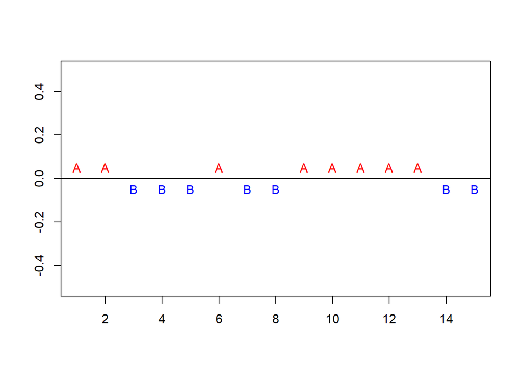

```
##
##  Runs Test - Two sided
##
## data:  anova_ex10_10$residuals
## Standardized Runs Statistic = -1.3282, p-value = 0.1841
```

```r
anova_ex10_10 <- aov(ex10_10$exam10_10.abundance~as.factor(ex10_10$exam10_10.layer))
runs.test(anova_ex10_10$residuals, alternative = "two.sided", plot = TRUE)
```

> Durbin-Watson test

```r
dwtest(anova_ex10_10, alternative = "less")
```

```
##
##  Durbin-Watson test
##
## data:  anova_ex10_10
## DW = 1.2926, p-value = 0.9829
## alternative hypothesis: true autocorrelation is less than 0
```

- Durbin-Watson test의 경우 DW = 1.2926로써 0보다 2와 가깝게 나왔으며, 2보다 작으므로 alternative = “less” 주었고 p-value = 0.9829로 귀무가설 “자기상관이 0 이다.”를 기각하지 못한다.
- 자기상관성이 없다고 독립인 건 아니지만 독립성 가정이 만족된다고 가정할 수 있을 것 같다.
- 정규성, 등분산성, 독립성이 만족되므로 ANOVA 검정을 실시한다.

```r
summary(anova_ex10_10)
```

```
##                                    Df Sum Sq Mean Sq F value   Pr(>F)
## as.factor(ex10_10$exam10_10.layer)  2  73.58   36.79   13.18 0.000937 ***
## Residuals                          12  33.50    2.79
## ---
## Signif. codes:  0 '***' 0.001 '**' 0.01 '*' 0.05 '.' 0.1 ' ' 1
```

- p-value는 0.0009로 유의수준보다 매우 작기 때문에 귀무가설을 기각할 수 있고 따라서 식물에 따라 파리의 개체수 분포가 다르다고 말할 수 있다.
- Kruskal-Wallis검정은 표본이 정규분포를 따르지 않지만 유사한 분포, 유사한 분산을 가질 때 적절한 비모수적 검정 방법이다.

```r
kruskal.test(ex10_10$exam10_10.abundance~as.factor(ex10_10$exam10_10.layer))
```

```
##
##  Kruskal-Wallis rank sum test
##
## data:  ex10_10$exam10_10.abundance by as.factor(ex10_10$exam10_10.layer)
## Kruskal-Wallis chi-squared = 8.72, df = 2, p-value = 0.01278
```

- 같은 데이터에 대해 비모수적 방법, 즉 rank를 이용한 검정을 진행해 본 결과 p-value는 0.01278로써 유의수준보다 작기 때문에 귀무가설을 기각할 수 있다.
- 따라서 식물에 따라 파리의 개체수 분포가 다르다고 말할 수 있다.

```r
library(pgirmess)
kruskalmc(ex10_10$exam10_10.abundance~as.factor(ex10_10$exam10_10.layer))
```

```
## Multiple comparison test after Kruskal-Wallis
## p.value: 0.05
## Comparisons
##     obs.dif critical.dif difference
## 1-2     6.8     6.771197       TRUE
## 1-3     7.6     6.771197       TRUE
## 2-3     0.8     6.771197      FALSE
```

- Multiple comparison test after Kruskal-Wallis 실시한 결과 유의수준 5%하에 1-2, 1-3 그룹간 차이가 있다고 말할 수 있다.

## 0.15 EXAMPLE 10.11

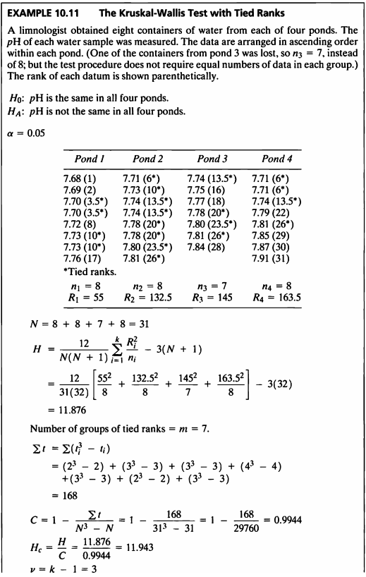

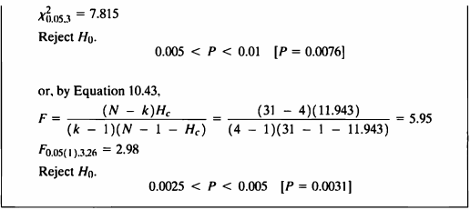

```r
#데이터셋
ex10_11%>%
  kbl(caption = "Dataset",escape=F) %>%
  kable_styling(bootstrap_options = c("striped", "hover", "condensed", "responsive"))
```

Dataset

| exam10_11.id | exam10_11.pond | exam10_11.ph |
| --- | --- | --- |
| 1 | 1 | 7.68 |
| 2 | 1 | 7.69 |
| 3 | 1 | 7.70 |
| 4 | 1 | 7.70 |
| 5 | 1 | 7.72 |
| 6 | 1 | 7.73 |
| 7 | 1 | 7.73 |
| 8 | 1 | 7.76 |
| 9 | 2 | 7.71 |
| 10 | 2 | 7.73 |
| 11 | 2 | 7.74 |
| 12 | 2 | 7.74 |
| 13 | 2 | 7.78 |
| 14 | 2 | 7.78 |
| 15 | 2 | 7.80 |
| 16 | 2 | 7.81 |
| 17 | 3 | 7.74 |
| 18 | 3 | 7.75 |
| 19 | 3 | 7.77 |
| 20 | 3 | 7.78 |
| 21 | 3 | 7.80 |
| 22 | 3 | 7.81 |
| 23 | 3 | 7.84 |
| 24 | 4 | 7.71 |
| 25 | 4 | 7.71 |
| 26 | 4 | 7.74 |
| 27 | 4 | 7.79 |
| 28 | 4 | 7.81 |
| 29 | 4 | 7.85 |
| 30 | 4 | 7.87 |
| 31 | 4 | 7.91 |

- 이 예제는 데이터 정렬 후 tied rank 데이터가 있는 비모수 anova 검정을 사용하는 예제이다.
- 데이터는 4개의 연못에서의 산성도를 측정한 데이터이다.
- 가설은 다음과 같다.

$$\begin{aligned}
H_0&: pH\ is\ the\ same\ in\ all\ four\ ponds.\\
H_A&: pH\ is\ not\ the\ same\ in\ all\ four\ ponds.\\
\end{aligned}$$

- 네 연못의 pH농도가 같은지 검정하기 위해 먼저 그룹별 정규성 검정을 한다.

> Shapiro-Wilk test로 세 그룹의 정규성을 평가하였다.

```r
shapiro.test(subset(ex10_11$exam10_11.ph,ex10_11$exam10_11.pond==1));shapiro.test(subset(ex10_11$exam10_11.ph,ex10_11$exam10_11.pond==2));shapiro.test(subset(ex10_11$exam10_11.ph,ex10_11$exam10_11.pond==3));shapiro.test(subset(ex10_11$exam10_11.ph,ex10_11$exam10_11.pond==4))
```

```
##
##  Shapiro-Wilk normality test
##
## data:  subset(ex10_11$exam10_11.ph, ex10_11$exam10_11.pond == 1)
## W = 0.95, p-value = 0.7113
```

```
##
##  Shapiro-Wilk normality test
##
## data:  subset(ex10_11$exam10_11.ph, ex10_11$exam10_11.pond == 2)
## W = 0.92959, p-value = 0.5123
```

```
##
##  Shapiro-Wilk normality test
##
## data:  subset(ex10_11$exam10_11.ph, ex10_11$exam10_11.pond == 3)
## W = 0.97382, p-value = 0.9245
```

```
##
##  Shapiro-Wilk normality test
##
## data:  subset(ex10_11$exam10_11.ph, ex10_11$exam10_11.pond == 4)
## W = 0.93368, p-value = 0.5502
```

- Shapiro-Wilk test로 1,2,3,4 그룹 모두 정규성 검정한 결과 p-value가 0.05보다 매우 크므로 모집단이 정규성을 따르지 않는다는 대립가설을 채택할 충분한 근거가 없다.
- 등분산성 검정으로 Bartlett’s Test를 진행하여 보자.

```r
class(ex10_11$exam10_11.pond)
```

```
## [1] "numeric"
```

- pond의 class가 numeric이므로 factor로 변경해서 등분산성 검정을 실시한다.

> Bartlett’s Test를 통해 네 그룹의 등분산성 검정을 진행하였다.

```r
bartlett.test(ex10_11$exam10_11.ph~as.factor(ex10_11$exam10_11.pond))
```

```
##
##  Bartlett test of homogeneity of variances
##
## data:  ex10_11$exam10_11.ph by as.factor(ex10_11$exam10_11.pond)
## Bartlett's K-squared = 8.8272, df = 3, p-value = 0.03168
```

- Bartlett’s Test의 유의확률은 p-value = 0.03168으로 유의수준 0.05보다 작으므로 등분산성이 아니라는 대립가설을 채택할 근거가 있다.
- 따라서 이 예제는 등분산성 가정을 만족하지 못한다.
- 등분산성 가정이 위배된 경우의 ANOVA test로 Welch’s test와 Brown and Forsythe 방법을 사용한다.

> Welch’s test는 그룹별 표본크기는 동일하나 모분산이 동일하지 않은 경우 더 우수하지만 데이터의 분포가 매우 치우친 분포인 경우 귀무가설을 쉽게 기각하는 단점이 있다.

> Brown and Forsythe 방법은 극단적인 평균값이 큰 분산과 관련 있는 경우에 검정력이 더 크다.
- 이 예제의 경우 Kruskal-Wallis test로 진행하였으므로 Kruskal-Wallis test를 진행하여 보자.

> 등분산성이 만족되지 않고 그룹별 샘플 수가 다르므로 비모수적 방법인 Kruskal-Wallis test 진행하여보자.

```r
kruskal.test(ex10_11$exam10_11.ph~as.factor(ex10_11$exam10_11.pond))
```

```
##
##  Kruskal-Wallis rank sum test
##
## data:  ex10_11$exam10_11.ph by as.factor(ex10_11$exam10_11.pond)
## Kruskal-Wallis chi-squared = 11.944, df = 3, p-value = 0.007579
```

- p=0.0076로 귀무가설을 기각하므로 PH는 모든 네 개 연못이 같다고 할 수 없다.
- Kruskal-Wallis test에서 처리간의 차이가 있다고 할 때, 추가적으로 어느 처리에서 차이가 있는지 확인하여보자.
- R에서 pgirmess 패키지의 kruskalmc() 함수를 사용하여 순위합 개념을 이용한 다중비교 검정을 하겠다.

```r
kruskalmc(ex10_11$exam10_11.ph, as.factor(ex10_11$exam10_11.pond))
```

```
## Multiple comparison test after Kruskal-Wallis
## p.value: 0.05
## Comparisons
##        obs.dif critical.dif difference
## 1-2  9.6875000     11.99368      FALSE
## 1-3 13.8392857     12.41464       TRUE
## 1-4 13.5625000     11.99368       TRUE
## 2-3  4.1517857     12.41464      FALSE
## 2-4  3.8750000     11.99368      FALSE
## 3-4  0.2767857     12.41464      FALSE
```

- 결과를 확인하여 보면, 유의수준 0.05하에서 1-3, 1-4 차이가 있다고 할 수 있다.
- 4 그룹의 분산을 각각 확인하여 보면,

```r
var(ex10_11[ex10_11$exam10_11.pond==1,3]);var(ex10_11[ex10_11$exam10_11.pond==2,3]);var(ex10_11[ex10_11$exam10_11.pond==3,3]);var(ex10_11[ex10_11$exam10_11.pond==4,3])
```

```
## [1] 0.0006839286
```

```
## [1] 0.001298214
```

```
## [1] 0.001228571
```

```
## [1] 0.005641071
```

- 각 그룹별 분산의 크기가 매우 작은 것을 볼 수 있다.
- 등분산성 가정이 위배되고 낮은 분산을 취했으므로 Welch’s test 비모수적 검정을 통하여 네 연못의 모평균 pH가 같은지 여부를 검정하여 보겠다.

```r
welch.test(ex10_11$exam10_11.ph~as.factor(ex10_11$exam10_11.pond),data=ex10_11)
```

```
##
##   Welch's Heteroscedastic F Test (alpha = 0.05)
## -------------------------------------------------------------
##   data : ex10_11$exam10_11.ph and as.factor(ex10_11$exam10_11.pond)
##
##   statistic  : 7.898356
##   num df     : 3
##   denom df   : 14.37493
##   p.value    : 0.002369379
##
##   Result     : Difference is statistically significant.
## -------------------------------------------------------------
```

- p-value가 유의수준 0.05보다 작기 때문에 귀무가설을 기각할 수 있으며 연못에 따라 pH농도의 모평균 차이가 있다고 말할 수 있다.
- 등분산성이 만족되지 않고 그룹별 샘플 수가 다를 때 사용할 수 있는 사후검정법으로 Dunnett’s C test를 진행하여보겠다.
- R에서 DescTools 패키지의 DunnettTest() 함수를 사용하겠다.

```r
library(DescTools)
DunnettTest(ex10_11$exam10_11.ph~as.factor(ex10_11$exam10_11.pond),control=1);DunnettTest(ex10_11$exam10_11.ph~as.factor(ex10_11$exam10_11.pond),control=2);DunnettTest(ex10_11$exam10_11.ph~as.factor(ex10_11$exam10_11.pond),control=3)
```

```
##
##   Dunnett's test for comparing several treatments with a control :
##     95% family-wise confidence level
##
## $`1`
##           diff       lwr.ci    upr.ci   pval
## 2-1 0.04750000 -0.011567833 0.1065678 0.1359
## 3-1 0.07053571  0.009394699 0.1316767 0.0209 *
## 4-1 0.08500000  0.025932167 0.1440678 0.0036 **
##
## ---
## Signif. codes:  0 '***' 0.001 '**' 0.01 '*' 0.05 '.' 0.1 ' ' 1
```

```
##
##   Dunnett's test for comparing several treatments with a control :
##     95% family-wise confidence level
##
## $`2`
##            diff      lwr.ci     upr.ci   pval
## 1-2 -0.04750000 -0.10656783 0.01156783 0.1358
## 3-2  0.02303571 -0.03810530 0.08417673 0.6749
## 4-2  0.03750000 -0.02156783 0.09656783 0.2866
##
## ---
## Signif. codes:  0 '***' 0.001 '**' 0.01 '*' 0.05 '.' 0.1 ' ' 1
```

```
##
##   Dunnett's test for comparing several treatments with a control :
##     95% family-wise confidence level
##
## $`3`
##            diff      lwr.ci       upr.ci   pval
## 1-3 -0.07053571 -0.13142822 -0.009643206 0.0206 *
## 2-3 -0.02303571 -0.08392822  0.037856794 0.6644
## 4-3  0.01446429 -0.04642822  0.075356794 0.8802
##
## ---
## Signif. codes:  0 '***' 0.001 '**' 0.01 '*' 0.05 '.' 0.1 ' ' 1
```

- 결과를 확인하여 보면 그룹 3과 그룹1, 그룹4와 그룹1의 p-value가 0.05보다 작게 나왔다.
- 따라서 연못1과 연못3, 그리고 연못1과 연못4의 모평균 pH농도가 다르다고 말할 수 있다.

## 0.16 EXAMPLE 10.12

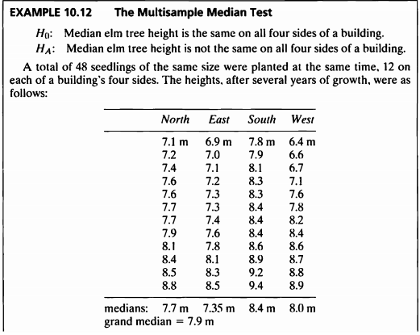

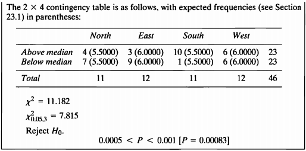

```r
#데이터셋
ex10_12%>%
  kbl(caption = "Dataset",escape=F) %>%
  kable_styling(bootstrap_options = c("striped", "hover", "condensed", "responsive"))
```

Dataset

| exam10_12.id | exam10_12.side | exam10_12.height |
| --- | --- | --- |
| 1 | 1 | 7.1 |
| 2 | 1 | 7.2 |
| 3 | 1 | 7.4 |
| 4 | 1 | 7.6 |
| 5 | 1 | 7.6 |
| 6 | 1 | 7.7 |
| 7 | 1 | 7.7 |
| 8 | 1 | 7.9 |
| 9 | 1 | 8.1 |
| 10 | 1 | 8.4 |
| 11 | 1 | 8.5 |
| 12 | 1 | 8.8 |
| 13 | 2 | 6.9 |
| 14 | 2 | 7.0 |
| 15 | 2 | 7.1 |
| 16 | 2 | 7.2 |
| 17 | 2 | 7.3 |
| 18 | 2 | 7.3 |
| 19 | 2 | 7.4 |
| 20 | 2 | 7.6 |
| 21 | 2 | 7.8 |
| 22 | 2 | 8.1 |
| 23 | 2 | 8.3 |
| 24 | 2 | 8.5 |
| 25 | 3 | 7.8 |
| 26 | 3 | 7.9 |
| 27 | 3 | 8.1 |
| 28 | 3 | 8.3 |
| 29 | 3 | 8.3 |
| 30 | 3 | 8.4 |
| 31 | 3 | 8.4 |
| 32 | 3 | 8.4 |
| 33 | 3 | 8.6 |
| 34 | 3 | 8.9 |
| 35 | 3 | 9.2 |
| 36 | 3 | 9.4 |
| 37 | 4 | 6.4 |
| 38 | 4 | 6.6 |
| 39 | 4 | 6.7 |
| 40 | 4 | 7.1 |
| 41 | 4 | 7.6 |
| 42 | 4 | 7.8 |
| 43 | 4 | 8.2 |
| 44 | 4 | 8.4 |
| 45 | 4 | 8.6 |
| 46 | 4 | 8.7 |
| 47 | 4 | 8.8 |
| 48 | 4 | 8.9 |

- 이 예제는 다표본 중위수 검정에 대한 예제이다.
- 데이터는 느릅나무의 길이를 건물의 4면에서 보았을 때의 높이를 기록한 데이터이다.
- 가설은 다음과 같다.

$$\begin{aligned}
H_0&:Median\ elm\ tree\ height\ is\ the\ same\ on\ all\ four\ sides\
of\ a\ building.\\
H_A&:Median\ elm\ tree\ height\ is\ not\ the\ same\ on\ all\ four\
sides\ of\ a\ building.\\
&medians:7.7m\ \ \ 7.35m\ \ \ 8.4m \ \ \ 8.0m,\ \ \ grand\
median=7.9m\\
\end{aligned}$$

- 느릅나무 높이의 중앙값이 건물의 4면 모두에서 동일한지 검정하기 위해 먼저 각 샘플에 대해 정규성 검정을 진행한다.

> Shapiro-Wilk test로 세 그룹의 정규성을 평가하였다.

```r
shapiro.test(subset(ex10_12$exam10_12.height,ex10_12$exam10_12.side==1));shapiro.test(subset(ex10_12$exam10_12.height,ex10_12$exam10_12.side==2));shapiro.test(subset(ex10_12$exam10_12.height,ex10_12$exam10_12.side==3));shapiro.test(subset(ex10_12$exam10_12.height,ex10_12$exam10_12.side==4))
```

```
##
##  Shapiro-Wilk normality test
##
## data:  subset(ex10_12$exam10_12.height, ex10_12$exam10_12.side == 1)
## W = 0.95381, p-value = 0.6932
```

```
##
##  Shapiro-Wilk normality test
##
## data:  subset(ex10_12$exam10_12.height, ex10_12$exam10_12.side == 2)
## W = 0.91943, p-value = 0.2812
```

```
##
##  Shapiro-Wilk normality test
##
## data:  subset(ex10_12$exam10_12.height, ex10_12$exam10_12.side == 3)
## W = 0.93364, p-value = 0.4203
```

```
##
##  Shapiro-Wilk normality test
##
## data:  subset(ex10_12$exam10_12.height, ex10_12$exam10_12.side == 4)
## W = 0.89877, p-value = 0.1529
```

- Shapiro-Wilk test로 1,2,3,4 그룹 모두 정규성 검정한 결과 p-value가 0.05보다 매우 크므로 모집단이 정규성을 따르지 않는다는 대립가설을 채택할 충분한 근거가 없다.
- 등분산성 검정으로 Bartlett’s Test를 진행하여 보자.

```r
class(ex10_12$exam10_12.side)
```

```
## [1] "numeric"
```

- side의 class가 numeric이므로 factor로 변경해서 등분산성 검정을 실시한다.

> Bartlett’s Test를 통해 네 그룹의 등분산성 검정을 진행하였다.

```r
bartlett.test(ex10_12$exam10_12.height~as.factor(ex10_12$exam10_12.side))
```

```
##
##  Bartlett test of homogeneity of variances
##
## data:  ex10_12$exam10_12.height by as.factor(ex10_12$exam10_12.side)
## Bartlett's K-squared = 6.4423, df = 3, p-value = 0.09196
```

- Bartlett’s Test의 유의확률은 p-value = 0.09196으로 유의수준 0.05보다 크므로 등분산성이 아니라는 대립가설을 채택할 근거가 없다.
- 따라서 이 예제는 등분산성 가정을 만족한다.
- 중앙값에 대한 검정 중 비모수적인 방법인 Mood’s median test를 수행하도록 한다.
- R에서 RVAideMemoire패키지의 mood.medtest() 함수를 사용하였다.

```r
median=median(ex10_12$exam10_12.height)
ex10_12$height <- ex10_12$exam10_12.height # height의 중앙값을 NA로 만들어줄 변수 생성
ex10_12$height[ex10_12$exam10_12.height == median]<-NA # height의 중앙값을 NA로 변경
ex10_12_na_rm<-na.omit(ex10_12) # height의 중앙값 7.9 제거
mood.medtest(ex10_12_na_rm$height~ex10_12_na_rm$exam10_12.side, data=ex10_12_na_rm, exact=F)
```

```
##
##  Mood's median test
##
## data:  ex10_12_na_rm$height by ex10_12_na_rm$exam10_12.side
## X-squared = 11.182, df = 3, p-value = 0.01078
```

- Mood’s median test 검정 결과 p-value=0.01078으로 유의수준 0.05하에 귀무가설을 기각할 충분한 근거가 있다.
- 따라서 건물 4면에 서 보는 방향에 따라 느릅나무의 길이에 대한 중앙값의 분포에 차이가 있다는 충분한 근거가 있다.

**카이제곱 검정**

- 해당 문제는 분할표자료에서 카이제곱 검정을 수행해도 된다.
- 검정과정  
  모든 관측치를 통합한 수 중위수를 구한다.  
  중위수보다 크거나 작은 관측치의 개수를 센다.  
  분할표를 작성한다.  
  카이제곱 검정을 한다.

|  | North | East | South | West |  |
| --- | --- | --- | --- | --- | --- |
| Above median | 4(5.5) | 3(6.0) | 10(5.5) | 6(6.0) | 23 |
| Not above median | 7(5.5) | 9(6.0) | 1(5.5) | 6(6.0) | 23 |
| Total | 11 | 12 | 11 | 12 | 46 |

$$\begin{aligned}
\chi^2=11.182,\ \ \ \chi_{0.05,3}^2=7.815\ \ \rightarrow Reject\ H_0.\\
0.0005<P<0.001\ \ \ \ [P=0.00083]
\end{aligned}$$

## 0.17 EXAMPLE 10.13

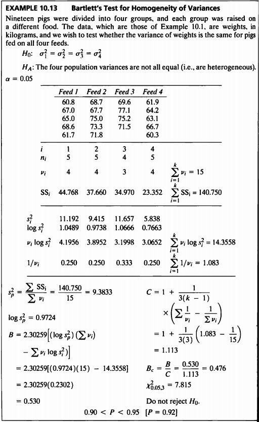

```r
#데이터셋
ex10_13%>%
  kbl(caption = "Dataset",escape=F) %>%
  kable_styling(bootstrap_options = c("striped", "hover", "condensed", "responsive"))
```

Dataset

| exam10_13.id | exam10_13.diet | exam10_13.weight |
| --- | --- | --- |
| 1 | 1 | 60.8 |
| 2 | 1 | 67.0 |
| 3 | 1 | 65.0 |
| 4 | 1 | 68.6 |
| 5 | 1 | 61.7 |
| 6 | 2 | 68.7 |
| 7 | 2 | 67.7 |
| 8 | 2 | 75.0 |
| 9 | 2 | 73.3 |
| 10 | 2 | 71.8 |
| 11 | 3 | 69.6 |
| 12 | 3 | 77.1 |
| 13 | 3 | 75.2 |
| 14 | 3 | 71.5 |
| 15 | 3 | NA |
| 16 | 4 | 61.9 |
| 17 | 4 | 64.2 |
| 18 | 4 | 63.1 |
| 19 | 4 | 66.7 |
| 20 | 4 | 60.3 |

- 이 예제는 Example 10.1 데이터를 사용하여 분산의 동질성 검정을 하는 예제이다.

$$\begin{aligned}
H_0&: \sigma_1^2=\sigma_2^2=\sigma_3^2=\sigma_4^2\\
H_A&: The\ four\ population\ variances\ are\ not\ all\ equal.\\
B&=(ln{s_p}^2)(\sum_{i=1}^k{\nu_i})-\sum_{i=1}^k\nu_i\
ln{s_i^2}=0.530\\\\
C&=1+\frac{1}{3(k-1)}(\sum_{i=1}^k{\frac{1}{\nu_i}-\frac{1}{\sum_{i=1}^k{\nu_i}}})=1.113\\
B_c&=\frac{B}{C}=0.476,\ \ \ \chi_{0.05,3}^2=7.815\ \ \ \ \ Do\ not\
reject\ H_0.\\
0.9&<P<0.95\ \ \ \ [P=0.92]
\end{aligned}$$

- Example 10.1에서 보았듯이 네 그룹 모두 정규성 검정 결과 p-value가 0.05보다 매우 컸고 따라서 정규성을 만족하지 않는다고 볼만한 충분한 근거가 없었다.  
  정규성을 만족한다는 사실을 바탕으로 그룹별 등분산성 검정인 Bartlett’s Test를 진행한 결과 p-value가 0.9243으로 유의수준 0.05보다 매우 큰 수치이므로 귀무가설을 기각할 수 없고 따라서 네 그룹의 분산이 다르다고 볼만한 충분한 근거가 없다.

## 0.18 EXAMPLE 10-14

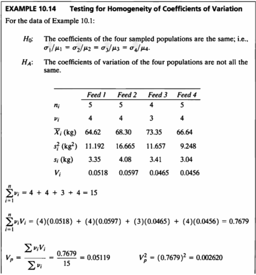

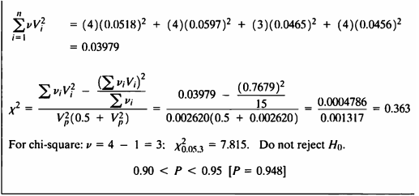

- 이 예제는 Example 10.1 데이터를 사용하여 변동계수에 대한 동질성 검정을 하는 예제이다.
- 본 검정의 가설은 다음과 같다.

$$\begin{aligned}
H_0&: The\ coefficients\ of\ the\ four\ sampled\ populations\ are\
the\ same:\ i.e., \\ \\
&\frac{\sigma_1}{\mu_1}= \frac{\sigma_2}{\mu_2}=
\frac{\sigma_3}{\mu_3}= \frac{\sigma_4}{\mu_4}\\ \\
H_A&: The\ coefficients\ of\ variation\ of\ the\ four\ populations\
are\ not\ all\ the\ same.\\
\end{aligned}$$

- Homogeneity of Coefficients of variation 검정하는 함수를 작성하였다.

```r
Homogeneity_CV<-function(n,m,ss){
  v<-n-1
  s<-sqrt(ss)
  cv<-s/m
  vv=sum(v*cv)
  vp=sum(v*cv)/sum(v)
  vp2=vp^2
  vv2=sum(v*(cv)^2)
  chisq=(vv2-(vv^2/sum(v)))/(vp2*(0.5+vp2))
  pvalue=pchisq(chisq,3, lower.tail=F)
  return(data.frame(chisq,pvalue))
}
```

```r
Homogeneity_CV(tapply(as.numeric(ex10_1$exam10_1.weight),as.factor(ex10_1$exam10_1.diet), length), tapply(as.numeric(ex10_1$exam10_1.weight),as.factor(ex10_1$exam10_1.diet), mean), tapply(as.numeric(ex10_1$exam10_1.weight),as.factor(ex10_1$exam10_1.diet), var))%>%
  kbl(caption = "Result") %>%
  kable_styling(bootstrap_options = c("striped", "hover", "condensed", "responsive"))
```

Result

| chisq | pvalue |
| --- | --- |
| 0.3873096 | 0.9428514 |